# Budweiser Case Study

Kati Schuerger, Will Sherman, Randy Kim

6/19/2021

#load libraries

```r
library(tidyverse)
library(ggthemes)
library(dplyr)
library(ggmap)
```

```r
library(maps)
library(caret)
library(class)
library(ggplot2)
library(grid)
library(gridExtra)
library(tidyr)
library(usmap)
library(highcharter)
library(broom)
library(tidyverse)
library(plotly)
library(e1071)
library(RColorBrewer)
```

#import the data

```r
breweries = read.csv(file.choose(), header = TRUE)
head(breweries, n = 5)
```

```
##   Brew_ID                      Name          City State
## 1       1        NorthGate Brewing    Minneapolis    MN
## 2       2 Against the Grain Brewery    Louisville    KY
## 3       3  Jack's Abby Craft Lagers    Framingham    MA
## 4       4 Mike Hess Brewing Company     San Diego    CA
## 5       5   Fort Point Beer Company San Francisco    CA
```

```r
beers = read.csv(file.choose(), header = TRUE)
head(beers, n = 5)
```

```
##                  Name Beer_ID   ABV IBU Brewery_id
## 1            Pub Beer    1436 0.050  NA        409
## 2         Devil's Cup    2265 0.066  NA        178
## 3 Rise of the Phoenix    2264 0.071  NA        178
## 4            Sinister    2263 0.090  NA        178
## 5       Sex and Candy    2262 0.075  NA        178
##                            Style Ounces
## 1            American Pale Lager     12
## 2        American Pale Ale (APA)     12
## 3                   American IPA     12
## 4 American Double / Imperial IPA     12
## 5                   American IPA     12
```

#1. How many breweries are present in each state?

```r
# check structure of breweries df
str(breweries)
```

```
## 'data.frame':    558 obs. of  4 variables:
##  $ Brew_ID: int  1 2 3 4 5 6 7 8 9 10 ...
##  $ Name   : chr  "NorthGate Brewing " "Against the Grain Brewery" "Jack's Abby Craft Lagers" "Mike Hess Brewing Company" ...
##  $ City   : chr  "Minneapolis" "Louisville" "Framingham" "San Diego" ...
##  $ State  : chr  " MN" " KY" " MA" " CA" ...
```

```r
## edit the State column to remove the blank space
## also convert to factor
breweries$State = as.factor(substr(breweries$State, 2, 3))

st_reg <- data.frame(State=state.abb, Region=state.region)
st_reg <- rbind(st_reg, data.frame(State="DC", Region="Northeast"))

breweries <- left_join(breweries,st_reg)
## confirm all rows have a Region
breweries %>% filter(is.na(Region) == TRUE)
```

```
## [1] Brew_ID Name    City    State   Region
## <0 rows> (or 0-length row.names)
```

```r
# Breweries by state
# BreweriesByState = data.frame(table(breweries$State, breweries$Region))
# colnames(BreweriesByState) = c("State","Region","Breweries")
# # removed from knit file = doesn't display correctly
#  BreweriesByState

# Breweries by state
BreweriesByState = data.frame(table(breweries$State))
colnames(BreweriesByState) = c("State","Breweries")
# removed from knit file = doesn't display correctly
BreweriesByState
```

```
##    State Breweries
## 1     AK         7
## 2     AL         3
## 3     AR         2
## 4     AZ        11
## 5     CA        39
## 6     CO        47
## 7     CT         8
## 8     DC         1
## 9     DE         2
## 10    FL        15
## 11    GA         7
## 12    HI         4
## 13    IA         5
## 14    ID         5
```

[output cut: 37 more lines]

#2. Merge beer data with the breweries data. Print the first 6 observations and the last six observations to check the merged file.

```r
#rename Brew_ID to match column name in beers (for merge)
breweries = breweries %>% rename(Brewery_id = Brew_ID)
head(breweries, n = 5)
```

```
##   Brewery_id                      Name          City State        Region
## 1          1        NorthGate Brewing    Minneapolis    MN North Central
## 2          2 Against the Grain Brewery    Louisville    KY         South
## 3          3  Jack's Abby Craft Lagers    Framingham    MA     Northeast
## 4          4 Mike Hess Brewing Company     San Diego    CA          West
## 5          5   Fort Point Beer Company San Francisco    CA          West
```

```r
#merge the data
dfBrews = merge(breweries, beers, by = c("Brewery_id"), all = FALSE)
head(dfBrews, n = 6)
```

```
##   Brewery_id             Name.x        City State        Region        Name.y
## 1          1 NorthGate Brewing  Minneapolis    MN North Central       Pumpion
## 2          1 NorthGate Brewing  Minneapolis    MN North Central    Stronghold
## 3          1 NorthGate Brewing  Minneapolis    MN North Central   Parapet ESB
## 4          1 NorthGate Brewing  Minneapolis    MN North Central  Get Together
## 5          1 NorthGate Brewing  Minneapolis    MN North Central Maggie's Leap
## 6          1 NorthGate Brewing  Minneapolis    MN North Central    Wall's End
##   Beer_ID   ABV IBU                               Style Ounces
## 1    2689 0.060  38                         Pumpkin Ale     16
## 2    2688 0.060  25                     American Porter     16
## 3    2687 0.056  47 Extra Special / Strong Bitter (ESB)     16
## 4    2692 0.045  50                        American IPA     16
## 5    2691 0.049  26                  Milk / Sweet Stout     16
## 6    2690 0.048  19                   English Brown Ale     16
```

```r
tail(dfBrews, n = 6)
```

```
##      Brewery_id                        Name.x          City State    Region
## 2405        556         Ukiah Brewing Company         Ukiah    CA      West
## 2406        557       Butternuts Beer and Ale Garrattsville    NY Northeast
## 2407        557       Butternuts Beer and Ale Garrattsville    NY Northeast
## 2408        557       Butternuts Beer and Ale Garrattsville    NY Northeast
## 2409        557       Butternuts Beer and Ale Garrattsville    NY Northeast
## 2410        558 Sleeping Lady Brewing Company     Anchorage    AK      West
##                         Name.y Beer_ID   ABV IBU                   Style Ounces
## 2405             Pilsner Ukiah      98 0.055  NA         German Pilsener     12
## 2406         Porkslap Pale Ale      49 0.043  NA American Pale Ale (APA)     12
## 2407           Snapperhead IPA      51 0.068  NA            American IPA     12
## 2408         Moo Thunder Stout      50 0.049  NA      Milk / Sweet Stout     12
## 2409  Heinnieweisse Weissebier      52 0.049  NA              Hefeweizen     12
## 2410 Urban Wilderness Pale Ale      30 0.049  NA        English Pale Ale     12
```

```r
# rename columns in merged data
colnames(dfBrews) = c("Brewery_ID","Brewery_Name","City","State","Region","Beer_Name",
                       "Beer_ID","ABV","IBU","Style","Ounces")
```

#3. Address the missing values in each column.

```r
# see nulls in merged data
sapply(dfBrews,function(x) sum(is.na(x)))
```

```
##   Brewery_ID Brewery_Name         City        State       Region    Beer_Name
##            0            0            0            0            0            0
##      Beer_ID          ABV          IBU        Style       Ounces
##            0           62         1005            0            0
```

```r
# show breakdown % missing
na_byState <- data.frame()
for(i in st_reg$State){
  na_byState[i,1]=length(which(grepl(i,dfBrews$State)))
  na_byState[i,2]=length(which(grepl(i,dfBrews$State) & is.na(dfBrews$IBU)))
}
names(na_byState) <- c("Beers_count","IBU_NAs_count")
na_byState %>% mutate(Percent_NA = round(IBU_NAs_count/Beers_count*100,digits=0))
```

```
##    Beers_count IBU_NAs_count Percent_NA
## AL          10             1         10
## AK          25             8         32
## AZ          47            23         49
## AR           5             4         80
## CA         183            48         26
## CO         265           119         45
## CT          27            21         78
## DE           2             1         50
## FL          58            21         36
## GA          16             9         56
## HI          27             9         33
## ID          30            13         43
## IL          91            52         57
## IN         139            48         35
## IA          30             5         17
## KS          23             4         17
## KY          21             7         33
## LA          19             9         47
## ME          27            20         74
## MD          21            11         52
## MA          82            31         38
## MI         162           124         77
## MN          55             9         16
## MS          11             0          0
## MO          42            13         31
## MT          40            17         42
## NE          25            16         64
## NV          11             3         27
## NH           8             6         75
## NJ           8             0          0
## NM          14             8         57
## NY          74            28         38
## NC          59            29         49
## ND           3             0          0
## OH          49            17         35
## OK          19             8         42
## OR         125            38         30
## PA         100            53         53
## RI          27             7         26
## SC          14             9         64
## SD           7             7        100
## TN           6             1         17
## TX         130            41         32
## UT          26            15         58
## VT          27            10         37
## VA          40             5         12
## WA          68            25         37
## WV           2             0          0
## WI          87            45         52
## WY          15             3         20
## DC           8             4         50
```

```r
### set seed
set.seed(7)

### impute values for ABV NAs
dfBrews$ABV = ifelse(is.na(dfBrews$ABV),
                     round(sample((mean(dfBrews$ABV, na.rm = TRUE) - sd(dfBrews$ABV, na.rm = TRUE)):
                                    (mean(dfBrews$ABV, na.rm = TRUE) + sd(dfBrews$ABV, na.rm = TRUE)),
                                  size = sum(is.na(dfBrews$ABV)), replace = T), 0), dfBrews$ABV)

# columns that have null values
colnames(dfBrews)[!complete.cases(t(dfBrews))]
```

```
## [1] "IBU"
```

```r
### impute values for IBU using Naive Bayes
# created editable data set
combined_df <- dfBrews

# split data frame into IBU known and IBU unknown
ibu_known <- combined_df[which(!is.na(combined_df$IBU)),]
ibu_unknown <- combined_df[which(is.na(combined_df$IBU)),]


###############################################################
# Training nB for classifying IBU
model <- naiveBayes(IBU~., data=ibu_known)


######### external cross validation ###########################
### multiple iterations
iterations = 100
masterAcc = matrix(nrow = iterations)

for(j in 1:iterations){
  train <- ibu_known[sample(seq(1:length(ibu_known$IBU)),
                            round(.7*length(ibu_known$IBU))),]
  test <- ibu_known[-sample(seq(1:length(ibu_known$IBU)),
                            round(.7*length(ibu_known$IBU))),]

  pred <- predict(model, train)
  t1 <- table(factor(pred, union(pred, train$IBU)),
              factor(train$IBU, union(pred, train$IBU)))
  CM <- confusionMatrix(t1)
  masterAcc[j] = CM$overall[1]
}
colMeans(masterAcc)
```

```
## [1] 0.8429705
```

```r
var(masterAcc)
```

```
##              [,1]
## [1,] 3.697411e-05
```

```r
# CM

# Impute nB
imp <- predict(model, ibu_unknown)
ibu_unknown_nB <- ibu_unknown

for(i in 1:nrow(ibu_unknown_nB)){
  ibu_unknown_nB$IBU[i] <- imp[i]
}

# attaching the predictions for unknown to know IBUs
combined_df_nB <- rbind(ibu_known,ibu_unknown_nB)
combined_df_nB <- combined_df_nB[order(combined_df_nB$Brewery_ID),]

head(combined_df_nB, n = 5)
```

```
##   Brewery_ID       Brewery_Name        City State        Region     Beer_Name
## 1          1 NorthGate Brewing  Minneapolis    MN North Central       Pumpion
## 2          1 NorthGate Brewing  Minneapolis    MN North Central    Stronghold
## 3          1 NorthGate Brewing  Minneapolis    MN North Central   Parapet ESB
## 4          1 NorthGate Brewing  Minneapolis    MN North Central  Get Together
## 5          1 NorthGate Brewing  Minneapolis    MN North Central Maggie's Leap
##   Beer_ID   ABV IBU                               Style Ounces
## 1    2689 0.060  38                         Pumpkin Ale     16
## 2    2688 0.060  25                     American Porter     16
## 3    2687 0.056  47 Extra Special / Strong Bitter (ESB)     16
## 4    2692 0.045  50                        American IPA     16
## 5    2691 0.049  26                  Milk / Sweet Stout     16
```

#4. Compute the median alcohol content and international bitterness unit for each state. Plot a bar chart to compare.

```r
sapply(combined_df_nB,function(x) sum(is.na(x)))
```

```
##   Brewery_ID Brewery_Name         City        State       Region    Beer_Name
##            0            0            0            0            0            0
##      Beer_ID          ABV          IBU        Style       Ounces
##            0            0            0            0            0
```

```r
BrewBeerABV = data.frame(combined_df_nB %>% group_by(State, Region) %>% summarise(ABV=median(ABV)))
```

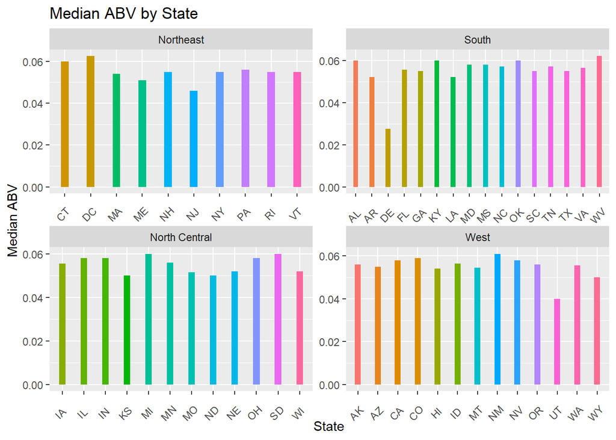

```r
BrewBeerABV %>% ggplot(mapping=aes(x=State,y=ABV,fill=State)) + geom_bar(stat="identity",width=0.3,position="dodge") +
  theme(legend.position="none",axis.text.x=element_text(angle=45,vjust=0.1))+
  ggtitle("Median ABV by State") + ylab("Median ABV") + xlab("State") + facet_wrap(~Region, scale = "free")
```

```r
BrewBeerIBU = data.frame(combined_df_nB %>% group_by(State, Region) %>% summarise(IBU=median(IBU)))
```

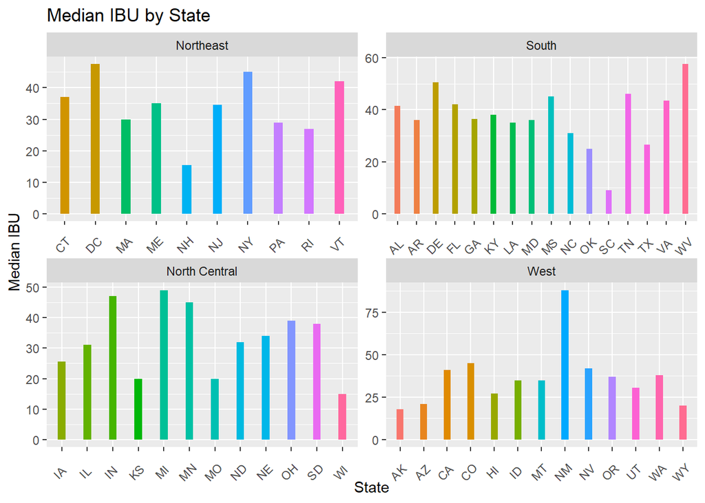

```r
BrewBeerIBU %>% ggplot(mapping=aes(x=State,y=IBU,fill=State)) + geom_bar(stat="identity",width=0.3,position="dodge") +
  theme(legend.position="none",axis.text.x=element_text(angle=45,vjust=0.1))+
  ggtitle("Median IBU by State") + ylab("Median IBU") + xlab("State") + facet_wrap(~Region, scale = "free")
```

#5. Which state has the maximum alcoholic (ABV) beer? Which state has the most bitter (IBU) beer?

```r
combined_df_nB[which.max(combined_df_nB$ABV),]
```

```
##     Brewery_ID            Brewery_Name    City State Region
## 384         52 Upslope Brewing Company Boulder    CO   West
##                                                Beer_Name Beer_ID   ABV IBU
## 384 Lee Hill Series Vol. 5 - Belgian Style Quadrupel Ale    2565 0.128  48
##                Style Ounces
## 384 Quadrupel (Quad)   19.2
```

```r
#Colorado at 12.8%

combined_df_nB[which.max(combined_df_nB$IBU),]
```

```
##      Brewery_ID            Brewery_Name    City State Region
## 1857        375 Astoria Brewing Company Astoria    OR   West
##                      Beer_Name Beer_ID   ABV IBU                          Style
## 1857 Bitter Bitch Imperial IPA     980 0.082 138 American Double / Imperial IPA
##      Ounces
## 1857     12
```

```r
#Oregon at 138
```

#6. Comment on the summary statistics and distribution of the ABV variable.

```r
# ABV quantiles for median ABV values
quantile(BrewBeerABV$ABV)
```

```
##     0%    25%    50%    75%   100%
## 0.0275 0.0540 0.0555 0.0580 0.0625
```

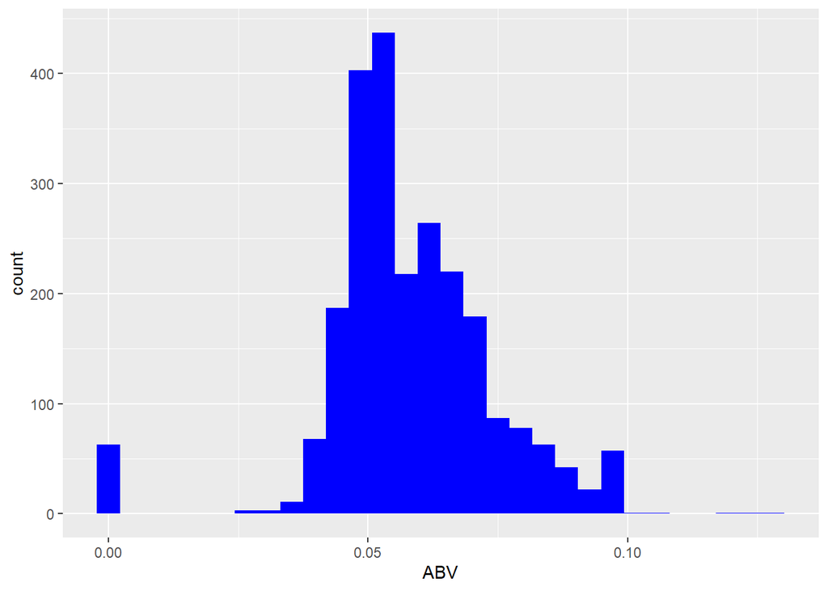

```r
# distribution of ABV
ggplot(data = dfBrews) +
  geom_histogram(mapping = aes(x = ABV), fill = "blue")
```

```r
## ABV distribution is slightly right skewed

# summary statistics for ABV
summary(dfBrews$ABV)
```

```
##    Min. 1st Qu.  Median    Mean 3rd Qu.    Max.
## 0.00000 0.05000 0.05600 0.05824 0.06700 0.12800
```

```r
# violin plot
## create new df for violin plot
combined_df_nB_2 = combined_df_nB
## create new "hold" column to put 1 value for violin plot to work
combined_df_nB_2$hold = 1
## check the data
head(combined_df_nB_2)
```

```
##   Brewery_ID       Brewery_Name        City State        Region     Beer_Name
## 1          1 NorthGate Brewing  Minneapolis    MN North Central       Pumpion
## 2          1 NorthGate Brewing  Minneapolis    MN North Central    Stronghold
## 3          1 NorthGate Brewing  Minneapolis    MN North Central   Parapet ESB
## 4          1 NorthGate Brewing  Minneapolis    MN North Central  Get Together
## 5          1 NorthGate Brewing  Minneapolis    MN North Central Maggie's Leap
## 6          1 NorthGate Brewing  Minneapolis    MN North Central    Wall's End
##   Beer_ID   ABV IBU                               Style Ounces hold
## 1    2689 0.060  38                         Pumpkin Ale     16    1
## 2    2688 0.060  25                     American Porter     16    1
## 3    2687 0.056  47 Extra Special / Strong Bitter (ESB)     16    1
## 4    2692 0.045  50                        American IPA     16    1
## 5    2691 0.049  26                  Milk / Sweet Stout     16    1
## 6    2690 0.048  19                   English Brown Ale     16    1
```

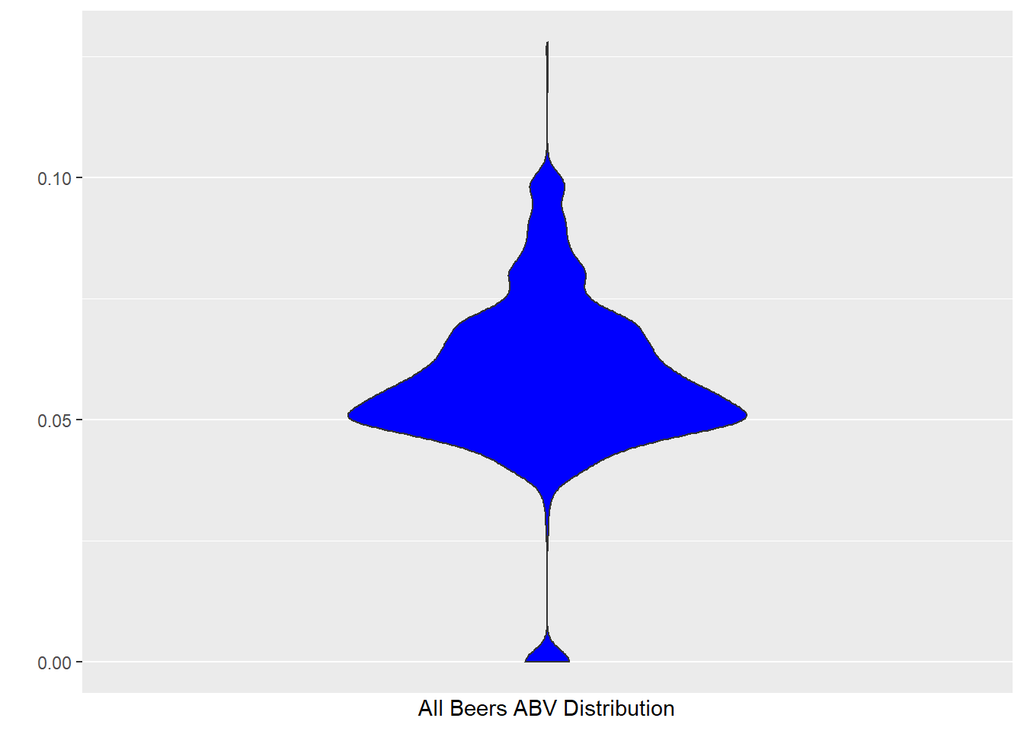

```r
## violin plot
combined_df_nB_2 %>% ggplot(aes(x = hold, y = ABV)) + geom_violin(fill = "blue") +
  xlab("All Beers ABV Distribution") +  ylab("") + scale_x_discrete(labels = NULL)
```

#7. Is there an apparent relationship between the bitterness of the beer and its alcoholic content? Draw a scatter plot. Make your best judgment of a relationship and EXPLAIN your answer.

```r
################## BY STATE #########################
# IBU
quantile(BrewBeerIBU$IBU)
```

```
##   0%  25%  50%  75% 100%
##    9   28   36   42   88
```

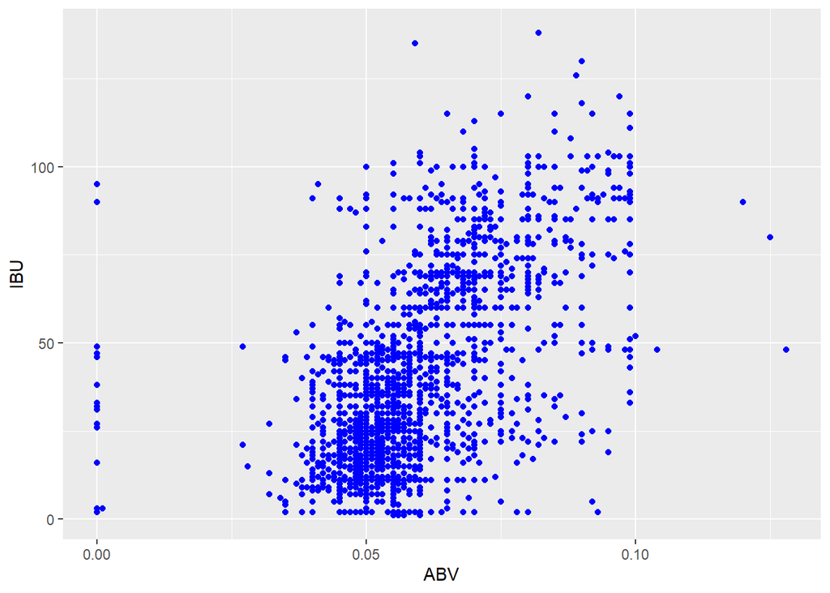

```r
####### quick scatterplot ##########################
ggplot(data = combined_df_nB) +
  geom_point(mapping = aes(x = ABV, y = IBU), color = "blue")
```

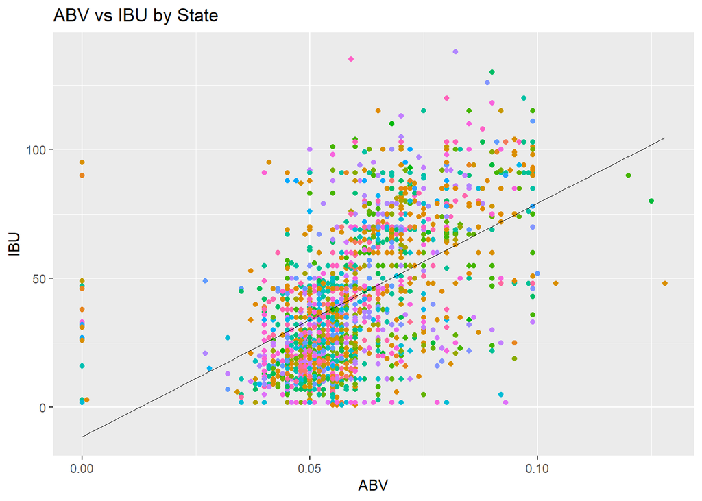

```r
# linear model fit
lm_fit = lm(ABV ~ IBU, data = combined_df_nB)
combined_df_nB %>% ggplot(aes(x=ABV,y=IBU,color=State)) +
  geom_point() +
  ggtitle("ABV vs IBU by State") +
  theme(legend.position = "none") +
  theme(legend.title = element_blank()) +
  geom_smooth(method="lm",se=FALSE,color="black",size=0.1)
```

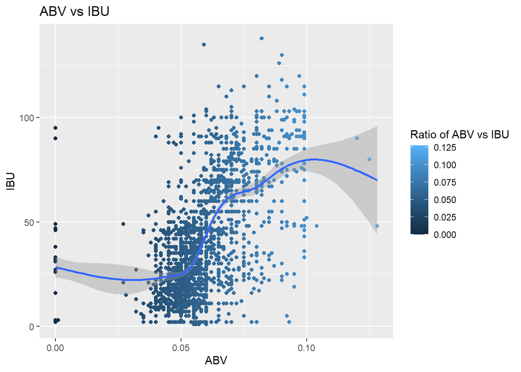

```r
####### relationship between ABV and IBU ####################
combined_df_nB %>% ggplot(aes(x=ABV, y=IBU, color=ABV)) +
  geom_point() +
  geom_smooth() +
  labs(color="Ratio of ABV vs IBU") +
  ggtitle("ABV vs IBU")
```

#7 continued

```r
########### ABV and IBU relationship by ALE / IPA #################

#check to be sure we aren't missing anything by looking for IPA
#check for 'India Pale Ale' instead of 'IPA'
sum(grepl("India Pale Ale",combined_df_nB$Style)) - sum(grepl("India Pale Ale",combined_df_nB$Style) & grepl("IPA", combined_df_nB$Style))
```

```
## [1] 0
```

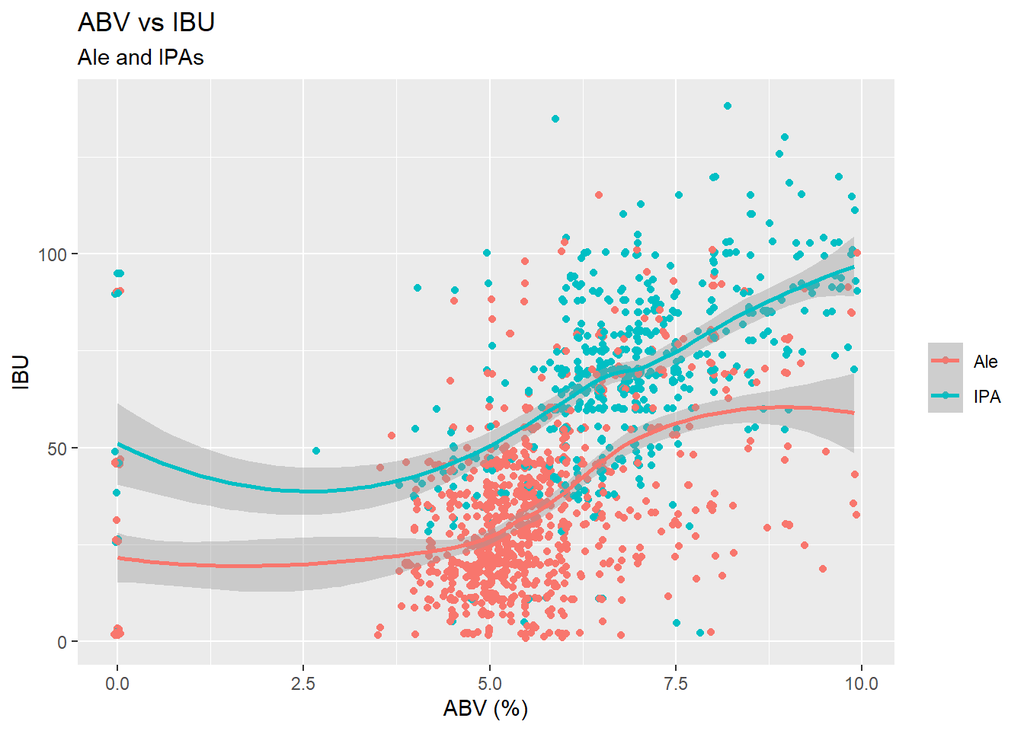

```r
ipas = filter(combined_df_nB, grepl("Ale|IPA",Style))
ipas = ipas %>% mutate(ipasType = ifelse(grepl("IPA",Style),"IPA","Ale"))

ipas %>% ggplot(aes(x=ABV *100, y= IBU, color=ipasType)) +
  geom_point(position='jitter') +
  geom_smooth() +
  ggtitle('ABV vs IBU') +
  labs(subtitle="Ale and IPAs")+
  xlab('ABV (%)') +
  theme(legend.title=element_blank())
```

```r
quantile(combined_df_nB$IBU)
```

```
##   0%  25%  50%  75% 100%
##    1   20   35   65  138
```

We can see that there is a positive correlation between IBU and ABV. We can see a big cluster around 5% ABV and we are predicting that they are regular 12 ounces of beers which according to NIAAA, in U.S., a beer contains between 4-7% ABV, with the average being 5%. Anything above estimates to be malt liquor which averaging to be 7% ABV. Just based on this, we couldn’t determine the causation so we decided to compare by Ale and IPAs and we can see that the majority of Ale has low ABV and IBU and the majority of IPA has high ABV and IBU. Budweiser has average 5% ABV and 7 IBU and we could carefully suggest to increase ABV within range of 5.6 - 5.8% and 19 -64 IBU to be in the competitive market.

#8. Budweiser would also like to investigate the difference with respect to IBU and ABV between IPAs (India Pale Ales) and other types of Ale (any beer with “Ale” in its name other than IPA). You decide to use KNN classification to investigate this relationship. Provide statistical evidence one way or the other. You can of course assume your audience is comfortable with percentages … KNN is very easy to understand conceptually.